Carolina Panthers Defensive Analysis

by Cristian Flores

Explosive Play Rate - The percentage of eligible plays that gain at least 15 yards on a pass or 10 yards on a run.

Defensive Success Rate - The percentage of eligible plays in which the defense allows less than 40% of yards to go on 1st down, 60% on 2nd down, or prevents a conversion on 3rd or 4th down.

Expected Points Added per 100 Plays - The change in expected points from the start to the end of a play, scaled to 100 eligible plays.

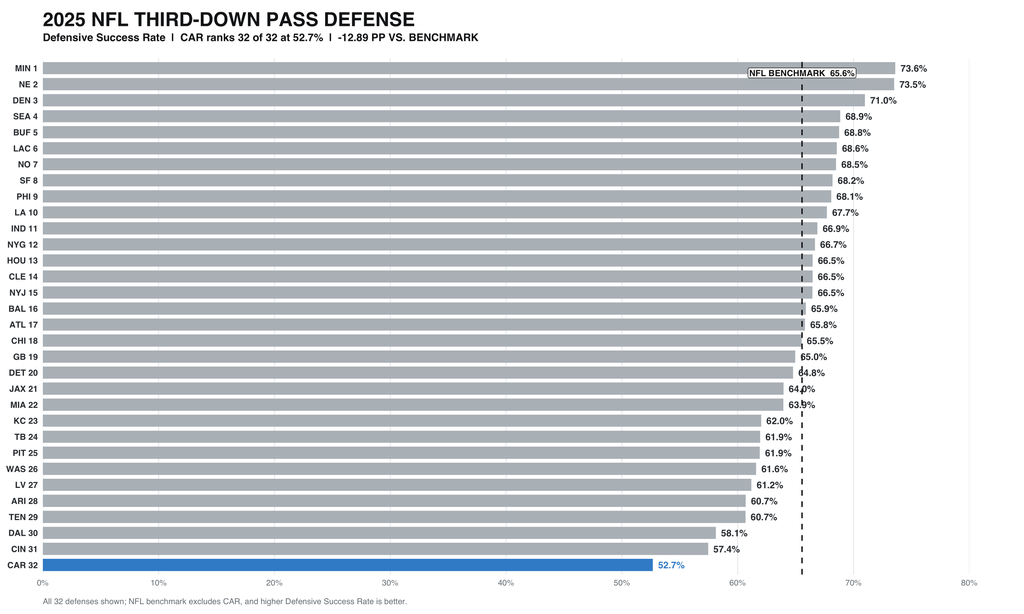

Key Takeaways:

Third-down pass defense was Carolina’s clearest weakness. The Panthers produced a 52.67% defensive success rate on third-down passes, 12.89 percentage points below the NFL benchmark, while allowing a statistically significant league-relative difference of +43.96 EPA per 100 plays.

On the other hand, Carolina was particularly strong on 1st-and-10. The Panthers produced a 53.40% Defensive Success Rate on 1st-and-10 while allowing explosive plays on 10.73% of those opportunities, with both results representing statistically significant strengths.

Overall, Carolina’s defense produced a mixed profile, ranking 16th in Defensive Success Rate while showing its strongest and weakest signals in specific down-and-play-type situations rather than overall performance.

Third-down Pass Defense Analysis:

When taking a deeper look at the Carolina Panthers’ third-down pass weakness, opponents targeted the defensive right on 43.48% of third-down throws, converting at a 56.67% rate. Intermediate passes of 10–19 air yards to the offense’s left (Carolina’s defensive right) were the clearest weakness. Carolina allowed **16 conversions on 21 intermediate-left targets (76.19%)**, with all 16 conversions completed at or beyond the sticks. This weakness persisted across 10 games against nine different opponents.

More broadly, Carolina’s third-down pass conversions came primarily through receptions at or beyond the sticks rather than yards after the catch. Of the 71 third-down pass conversions allowed, **55 (77.46%) were completed at or beyond the line to gain**, compared with only 16 (22.54%) from shorter completions converted through YAC. Finally, this weakness was not limited to a particular third-down distance, as Carolina performed relatively poorly on third-and-short, third-and-medium, and third-and-long.

First-down Defense Analysis:

Despite Carolina being good on first-and-10 overall, the middle of the field was a weakness against both the run and pass. Carolina was successful on just 40.43% of 47 middle runs at holding the offense to fewer than four yards and produced only a 34.29% success rate across 35 middle pass targets. Combined, **opponents succeeded on 51 of 82 middle opportunities (62.20%)**, with those successes occurring in 15 games against 13 unique opponents.

In the passing game, Carolina’s defense was strongest against deep targets but vulnerable in the short and intermediate depth ranges. They stopped 15 of 17 deep targets, while their success rate fell to 37.66% against short targets and 43.33% against intermediate targets. Intermediate passes were particularly dangerous, as **11 of 30 resulted in explosive plays (36.67%)**.